# Analysis on the Relationship CPU Utilization and Temperature on Raspberry Pi Devices

Link to Github page: https://github.com/CuriousChum/jsc370

## Introduction

#### Research Question

How does resource utilization affect temperature across different Raspberry Pi configurations and application states, and can we identify patterns in this relationship that predict thermal behavior?

## Methods

### Dataset Description

The dataset used in this analysis was constructed and collected by researched is the Queen's Telecommunation Research Lab (TRL), led by Ruslan Kain. It contains resource usage information from four heterogeneous Raspberry Pi 4 devices, with different RAM sizes (2GB, 4GB, 8GB) and CPU frequencies (1200MHz, 1500MHz, 1800MHz), measured under different application usages including gaming, streaming, augmented reality, mining, and idling. The data is collected in ~5 second intervals using the `PsUtil` Python package.

Since the dataset is separated into multiple smaller datasets for each device and application usage patterns (consistent pattern vs. random), this exploratory analysis will use only one for each device and use the data with consistent usage pattern.

### Data Wrangling

The dataset will be subsetted on the following columns

- `cpu`
- `state`
- `memory`
- `cpu_freq`
- `net_upload_rate`
- `net_download_rate`
- `temp`

This choice is made based on domain-specific knowledge, specifically, CPU, memory, and network activity is known to generate heat, so they are included to account for confounding effects. The state is also kept to observe resource activity difference between states.

Since each application runs on its own, it is independent of each other.So, the dataset will be separated into time windows per state since the device runs an application for a window of time and analyse each window as independent samples.

### Feature Engineering

Resource activity data can contain a lot of noise especially for the CPU, upload/download rate (network), and temperature perhaps due to inherent jitter or measurement variance. For those columns, we will calculate a moving average to smoothen them out. The window size and weighing method is chosen based on the type of resource. Specifically, CPU and upload/download rate is unweighted, while temperature is weighted with an exponential window.

Memory usage on its own does affect the utilization of other resources since this can mean nothing is going on at the moment. So, the percentage change in RAM usage is added to account for memory usage by the device for each application.

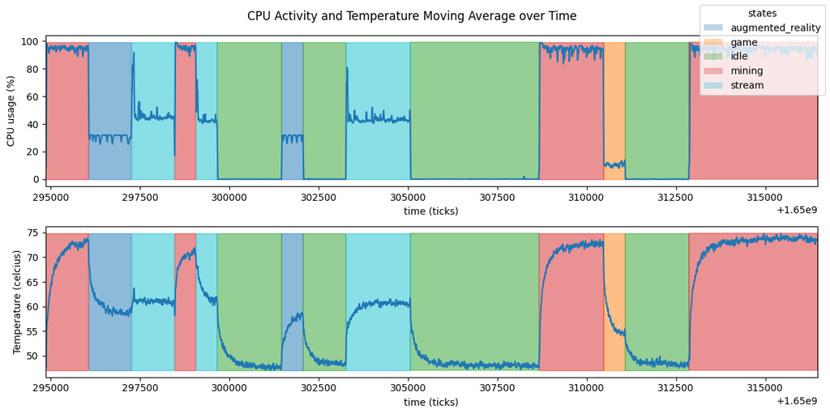

## Preliminary Results

Furthermore, the temperature seems to increase/decrease quickly when the CPU utilization changes rapidly due to change of device application state, and plateauing to a stable temperature that is consistent for each state. This might imply that the device temperature change has some relationship to CPU utilization.

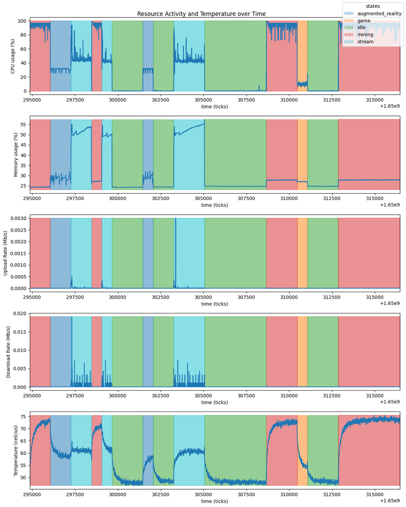

Finally, we see that the network activity is relevant when the device is streaming, specifically, the download rate increases. However, on any other states, the device shows little to no network activity, so the upload rate will be removed from future analyses.

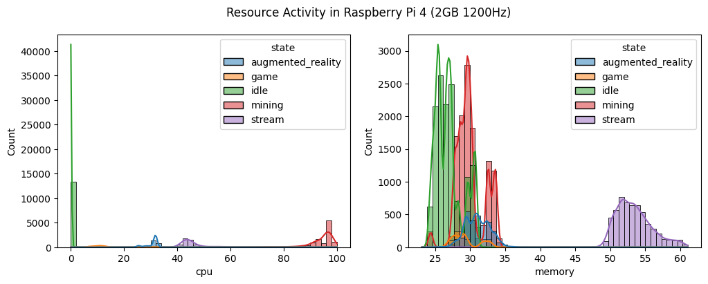

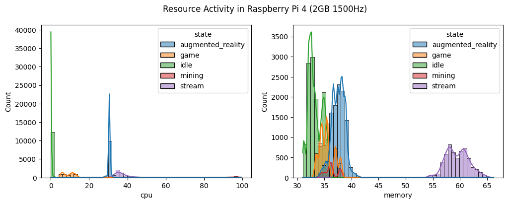

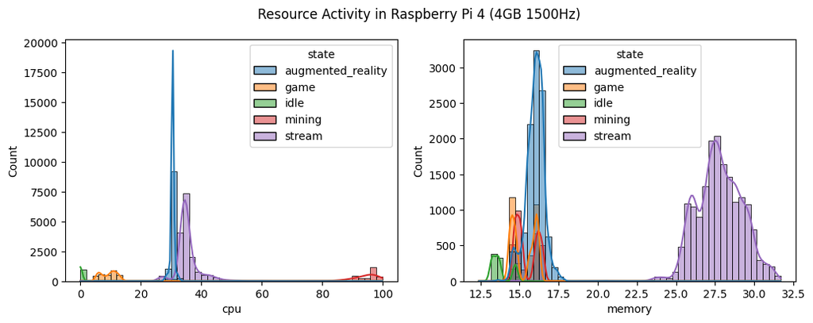

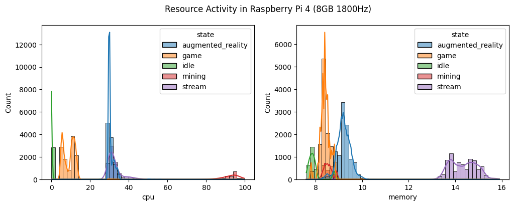

[output not shown]